# En överblick över dödsorsaker bland kvinnor och män

## Introduktion

Ingen människa kan se in i framtiden, men en sak vi alla med säkerhet vet kommer att ske är att vi kommer att dö. För vissa är döden en skrämmande tanke som helst undviks medan andra ser den som en naturlig del av livet. Själv tillhör jag den första gruppen, vilket gör det lite obekvämt att dyka ner i detta ämne. Men oavsett hur vi känner inför döden kan det vara värdefullt att veta vad vi faktiskt dör av. För vissa kan det handla om att stilla sin nyfikenhet, för andra kanske det är en möjlighet att kunna reflektera över hur vi lever idag. Så hur ser dödsorsakerna ut, dör kvinnor och män av samma orsaker? Har vad vi dör av ändrats över tid? Och är det några dödsorsaker som sticker ut? Det tar vi reda på här!

## Data

För att undersöka dödsorsakerna för kvinnor och män har data hämtats från Socialstyrelsens statistikdatabas för dödsorsaker. Datan laddades ner som en semikolonseparerad csv-fil. Datan består av samlingsnamn av diagnoser, antalet döda per 100 000 kvinnor och män för varje diagnos från år 1997 till år 2023. Nedan kan vi se en överblick över datan efter hantering av saknad data och bearbetning. Exempelvis fanns det inte någon data över antalet döda per 100 000 för Covid-19 mellan åren 1997-2019, vilket inte är så konstigt eftersom Covid-19 inte fanns då. Dessa värden har därför ersatts med nollor.

|  | Diagnos | Kön | 1997 | 1998 | 1999 | 2000 | 2001 | 2002 | 2003 | 2004 | ... | 2014 | 2015 | 2016 | 2017 | 2018 | 2019 | 2020 | 2021 | 2022 | 2023 |
| --- | --- | --- | --- | --- | --- | --- | --- | --- | --- | --- | --- | --- | --- | --- | --- | --- | --- | --- | --- | --- | --- |
| 0 | Alkoholrelaterad dödlighet | Män | 35.33 | 34.80 | 34.95 | 33.99 | 36.84 | 35.20 | 36.96 | 37.74 | ... | 30.78 | 31.26 | 29.71 | 29.00 | 29.01 | 29.02 | 29.91 | 30.47 | 30.19 | 30.44 |
| 1 | Alkoholrelaterad dödlighet | Kvinnor | 7.89 | 9.18 | 8.57 | 8.96 | 8.74 | 9.01 | 9.36 | 9.63 | ... | 9.69 | 9.41 | 9.09 | 9.46 | 9.17 | 8.88 | 10.15 | 9.91 | 10.02 | 10.57 |
| 2 | Covid19 (virus påvisat och virus ej påvisat) | Män | 0.00 | 0.00 | 0.00 | 0.00 | 0.00 | 0.00 | 0.00 | 0.00 | ... | 0.00 | 0.00 | 0.00 | 0.00 | 0.00 | 0.00 | 97.96 | 59.35 | 38.81 | 23.37 |
| 3 | Covid19 (virus påvisat och virus ej påvisat) | Kvinnor | 0.00 | 0.00 | 0.00 | 0.00 | 0.00 | 0.00 | 0.00 | 0.00 | ... | 0.00 | 0.00 | 0.00 | 0.00 | 0.00 | 0.00 | 85.38 | 42.81 | 28.48 | 17.09 |
| 4 | Läkemedels och narkotikaförgiftningar | Män | 7.44 | 6.81 | 6.81 | 7.11 | 9.27 | 8.17 | 7.30 | 6.96 | ... | 12.90 | 13.22 | 12.21 | 12.56 | 10.56 | 10.27 | 10.25 | 8.89 | 10.49 | 9.52 |

5 rows × 29 columns

## Dödsorsaker idag

Vi börjar med att undersöka de vanligaste dödsorsakerna för män respektive kvinnor år 2023. Detta visualiseras i en barplot som skapats med seaborn. Figuren visar antalet döda per 100 000 män respektive kvinnor på y-axeln och dödsorsak (diagnos) på x-axeln.

Som vi kan se i figuren är de två överlägset vanligaste dödsorsakerna för både män och kvinnor Cirkulationsorganens sjukdomar, vilket är olika typer av hjärt- och krälsjukdomar och Tumörer, det vill säga cancer.

Vidare är den tredje vanligaste dödsorsaken för män Yttre orsaker till sjukdom och död i tätt följd av Andningsorganens sjukdomar. Medan det för kvinnor i stället är Psykiska sjukdomar och syndrom samt beteendestörningar som tar trejdeplatsen med Sjukdomar i nervsystemet som fjärde vanligaste dödsorsaken.

Vi kan också utifrån plotten se att det verkar vara störst skillnad mellan män och kvinnor i antal döda på 100 000 för dödsorsakerna Yttre orsaker till sjukdom och död och Psykiska sjukdomar och syndrom samt beteendestörningar. Även Alkoholrelaterad dödlighet ser ut att ha en större skillnad mellan könen.

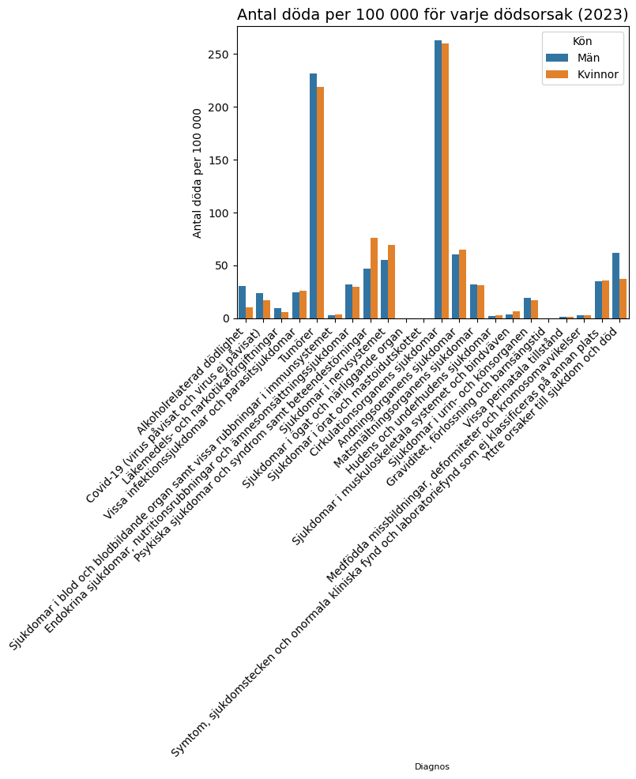

En kanske fördomsfull förklaring till varför så många fler män än kvinnor dör i Yttre orsaker till sjukdom och död kan vara att män i större utsträckning utsätter sig för större risker, så som att köra snabbt. Vilket kan resultera i en bilolycka med dödlig utgång. Men en sådan teori behöver självklart vidare analyser för att kunna bekräftas.

## Dödsorsaker år 1997

Vi går raskt vidare till hur det såg ut under år 1997.

I figuren nedan kan vi se de två vanligaste dödsorsakerna år 2023 (Cirkulationsorganens sjukdommar och Tumörer) även var de vanligaste dödsorsakerna år 1997 för de båda könen. Vidare är den tredje vanligaste dödsorsaken för både män och kvinnor Andningsorganens sjukdomar, vilket skiljer sig från år 2023. Vi ser även att Yttre orsaker till död och sjukdom är den fjärde vanligaste dödsorsaken för män medan det för kvinnor är Psykiska sjukdomar och syndrom samt beteendestörningar.

Vidare kan vi sa att skillnaden mellan antal döda per 100 000 män respektive kvinnor verkar vara som störst mellan könen för dödsorsakerna Alkoholrelaterad dödlighet, Yttre orsaker till sjukdom och död samt Tumörer.

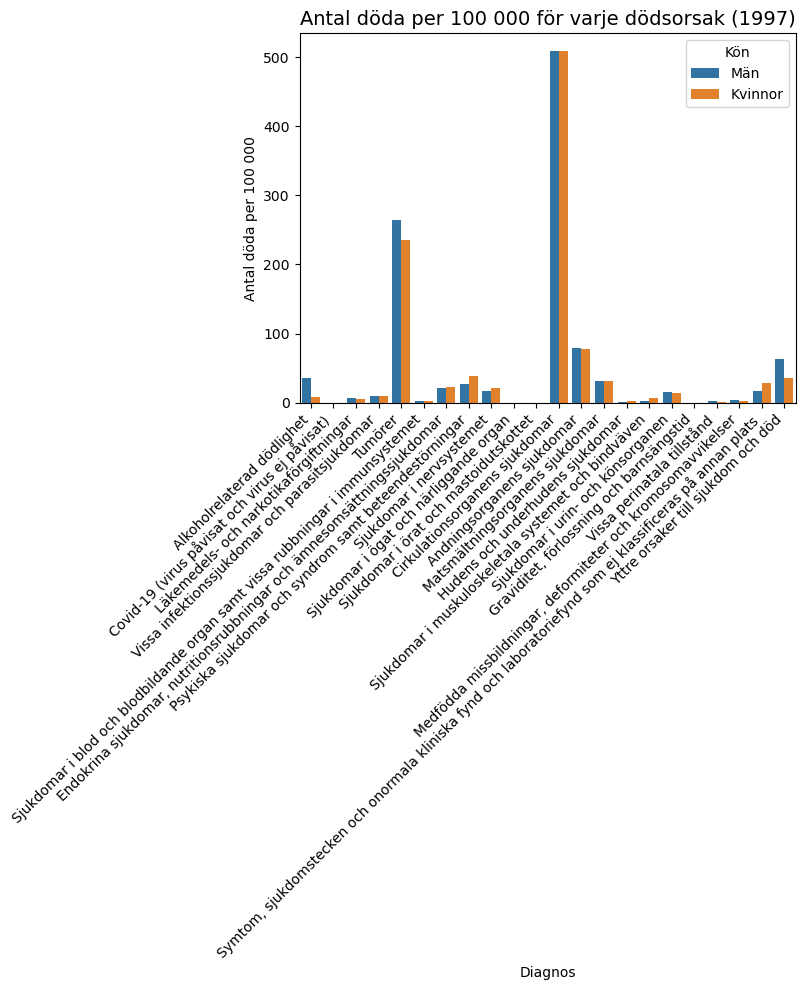

Att antalet döda i andningsorganens sjukdomar per 100 000 finns med på topp tre vanligaste dödsorsakerna för män och kvinnor år 1997 men inte år 2023 kanske kan förklaras av den syn vi idag har på rökning jämför med år 1997. Det har sedan dess till exempelvis blivit otillåtet att röka på restauranger och mer nyligen även att röka på uteserveringar.

## Vilka dödsorsaker har förändrats mest?

I de tidiagre figurerna framgår att antal döda per 100 000 män respektive kvinnor, fördelat på dödsorsak, har förändrats mellan åren 1997 och 2023.

Det är dock svårt at utifrån figurerna identifiera var de största förändringarna har skett, även om det är uppenbart att antalet döda i Cirkulationsorganens sjukdomar har minskat kraftigt under perioden. Vi undersöker därför var de största procentuella förändningarna i antalet döda per 100 000 har skett. För varje dödsorsaker beräknar vi den procentuella förändningen enligt följande formel:

$$ \text{Procentuell förändring} = \frac{\text{Antal döda per } 100 000 \text{ år } 2023 - \text{ Antal döda per } 100 000 \text{ år } 1997}{\text{ Antal döda per } 100 000 \text{ år } 1997}\times 100.$$

Detta illusteraras sedan i figurerna nedan.

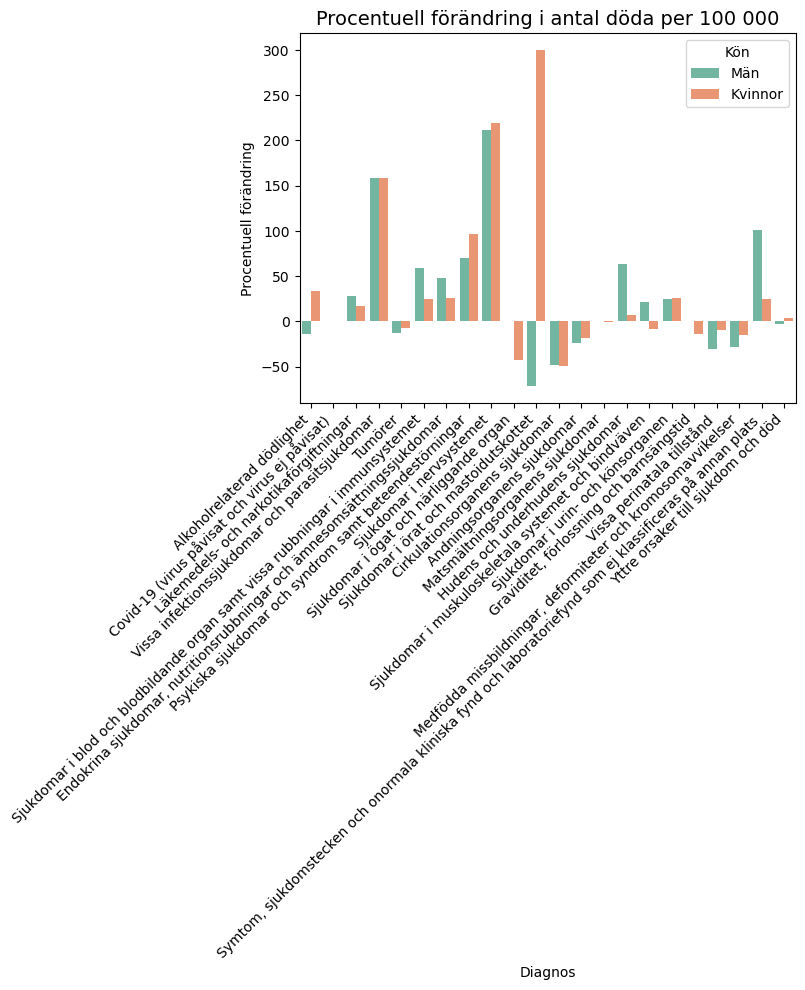

Den procentuella förändringen kan dock vara missvisande vid små värden. Därför kollar vi även på den numeriska differansen.

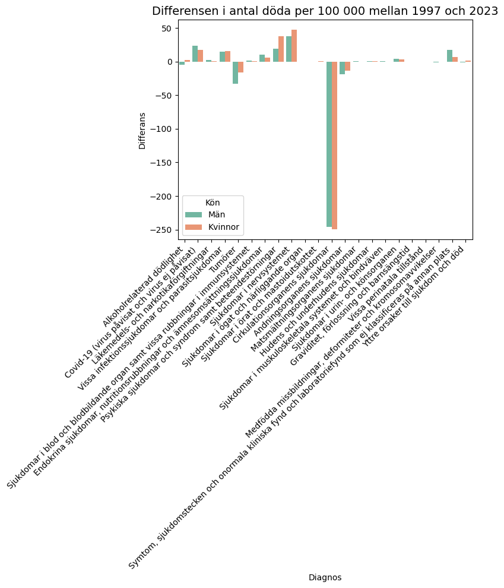

I figuren ovan ser vi exempelvis att Sjukdomar i örat och mastoidutskottet för kvinnor knappt har haft någon numerisk förändring i antlet döda per 100 000. Medan den procentuella förändringen är närmare 300%. Därför är det bra att ta både numerisk och procentuell förändring i beaktning.

## Trendspaning

Vi har tidigare jämfört åren 1997 och 2023 men har det skett något där emellan och kan vi se några trender? Vi undersöker detta genom att kolla på linjeplottat för antalet döda per 100 000 män respektive kvinnor.

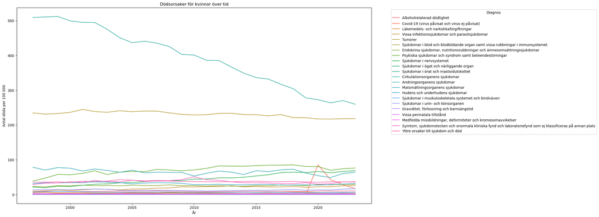

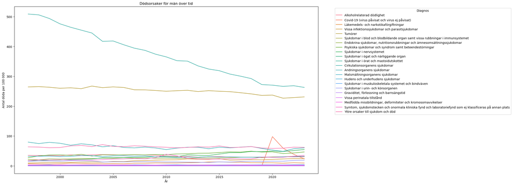

## Sammanfattning

Sammanfattningsvis kan vi konstatera att de absolut vanligaste dödsorsakerna för både män och kvinnor under åren 1997-2023 är Cirkulationsorganens sjukdomar samt Tumörer, dvs kvinnor och män dör av samma orsaker. Å andra sidan har könen olika dödsorsaker på plats tre och nedåt, så en viss skilland finns i de mindre vanliga dödsorsakerna. Vad beträffar "dödstrender" så ser vi att antalet som dör av Cirkulationsorganens sjukdomar (per 100 000) avtar medan övriga dödsorsaker är relativt stabila för båda könen med undantag för Covid-19 som har en tydlig topp 2020. Det vore intressant att veta om Cirkulationsorganens sjukdommars nedåtgående trend fortsätter eller om den planar ut likt de andra dödsorsakerna, den som lever får se.

### Källa

Dödsorsaker [internet]. Stockholm: Socialstyrelsen. [citerad 2024-12-29]. Tillgänglig från: https://www.socialstyrelsen.se/statistik-och-data/statistik/statistikdatabasen/